# Data description

```python
df_copy.describe()
```

|  | num_reactions | num_comments | num_shares | num_likes | num_loves | num_wows | num_hahas | num_sads | num_angrys |
| --- | --- | --- | --- | --- | --- | --- | --- | --- | --- |
| count | 6999.000000 | 6999.000000 | 6999.000000 | 6999.000000 | 6999.000000 | 6999.000000 | 6999.000000 | 6999.000000 | 6999.000000 |
| mean | 224.994571 | 225.552079 | 40.258608 | 209.946707 | 12.751536 | 1.252893 | 0.697957 | 0.232605 | 0.110159 |
| std | 452.880746 | 892.743010 | 132.046903 | 439.550330 | 40.106872 | 8.725551 | 3.970912 | 1.481105 | 0.688582 |
| min | 0.000000 | 0.000000 | 0.000000 | 0.000000 | 0.000000 | 0.000000 | 0.000000 | 0.000000 | 0.000000 |
| 25% | 17.000000 | 0.000000 | 0.000000 | 17.000000 | 0.000000 | 0.000000 | 0.000000 | 0.000000 | 0.000000 |
| 50% | 58.000000 | 4.000000 | 0.000000 | 57.000000 | 0.000000 | 0.000000 | 0.000000 | 0.000000 | 0.000000 |
| 75% | 216.000000 | 22.000000 | 4.000000 | 182.000000 | 3.000000 | 0.000000 | 0.000000 | 0.000000 | 0.000000 |
| max | 4710.000000 | 20990.000000 | 3424.000000 | 4710.000000 | 657.000000 | 278.000000 | 157.000000 | 51.000000 | 31.000000 |

Engagement metrics consist:

- type of pages posts
- number of reactions
- number of comments
- number of shares
- number of likes
- number of loves
- number of wows
- number of hahas
- number of sads
- number of angrys

# Data exploration and visualization

Percentage of facebook pages posts type.

Most: **Photos** Least: **Links**

```
(-1.1160792851010979,
 1.1119290737673317,
 -1.1161337648246337,
 1.111874594043796)
```

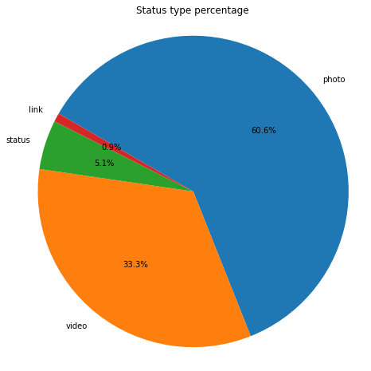

```python
plt.figure(figsize = [8,8])
sorted_counts = df_copy['status_type'].value_counts()

plt.pie(sorted_counts, labels = sorted_counts.index, autopct = '%1.1f%%', startangle = 150, counterclock = False);
plt.title('Status type percentage')
plt.axis('square')
```

## links

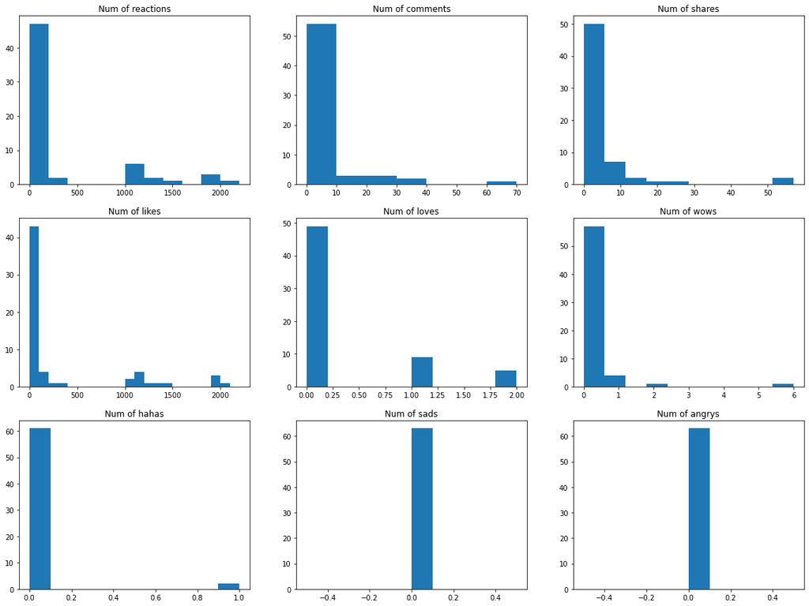

```python
plt.figure(figsize = [20, 15])


plt.subplot(3, 3, 1) # 3 row, 3 cols, subplot 1
bins = np.arange(0, link['num_reactions'].max()+4, 200)
plt.hist(data = link, x = 'num_reactions', bins=bins);
plt.title('Num of reactions');

plt.subplot(3, 3, 2)
bins = np.arange(0, link['num_comments'].max()+4, 10)
plt.hist(data = link, x = 'num_comments', bins=bins);
plt.title('Num of comments');

plt.subplot(3, 3, 3)
plt.hist(data = link, x = 'num_shares');
plt.title('Num of shares');

plt.subplot(3, 3, 4)
bins = np.arange(0, link['num_likes'].max()+4, 100)
plt.hist(data = link, x = 'num_likes', bins=bins);
plt.title('Num of likes');

plt.subplot(3, 3, 5)
plt.hist(data = link, x = 'num_loves');
plt.title('Num of loves');

plt.subplot(3, 3, 6)
plt.hist(data = link, x = 'num_wows');
plt.title('Num of wows');

plt.subplot(3, 3, 7)
plt.hist(data = link, x = 'num_hahas');
plt.title('Num of hahas');

plt.subplot(3, 3, 8)
plt.hist(data = link, x = 'num_sads');
plt.title('Num of sads');

plt.subplot(3, 3, 9)
plt.hist(data = link, x = 'num_angrys');
plt.title('Num of angrys');
```

we have number of reactions with a median of **50** and a mean of **370.14**. Number of comments with a median of **1** and a mean of **5.69**. Number of emotions are **nearly 0**.

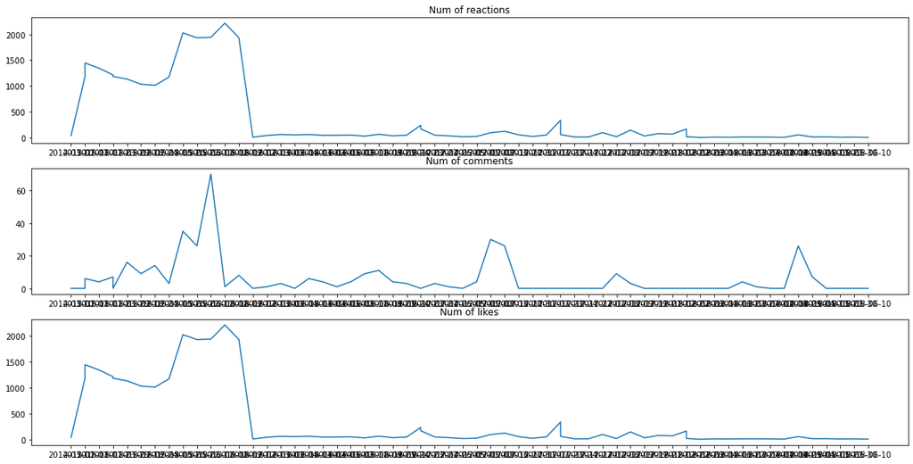

```python
plt.figure(figsize = [20, 10])
plt.subplot(3, 1, 1)
plt.plot(link['status_published'],link['num_reactions'])
plt.title('Num of reactions');

plt.subplot(3, 1, 2)
plt.plot(link['status_published'],link['num_comments'])
plt.title('Num of comments');

plt.subplot(3, 1, 3)
plt.plot(link['status_published'],link['num_likes'])
plt.title('Num of likes');
```

## photos

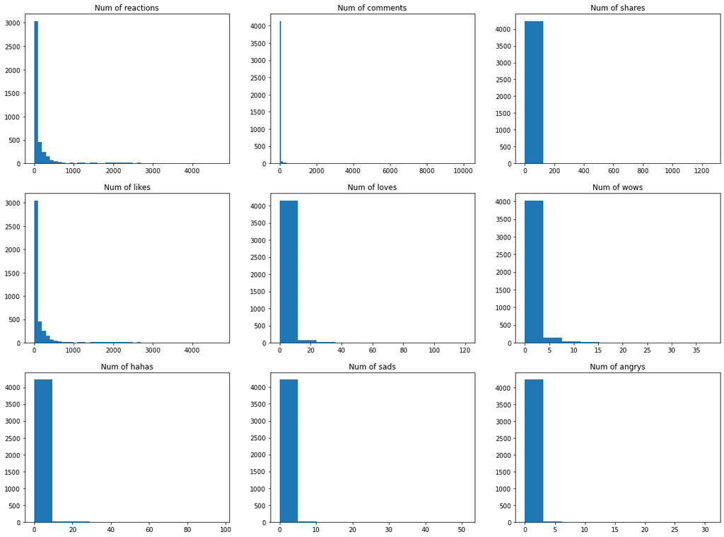

```python
plt.figure(figsize = [20, 15])


plt.subplot(3, 3, 1) # 3 row, 3 cols, subplot 1
bins = np.arange(0, photo['num_reactions'].max()+4, 100)
plt.hist(data = photo, x = 'num_reactions', bins=bins);
plt.title('Num of reactions');

plt.subplot(3, 3, 2)
bins = np.arange(0, photo['num_comments'].max()+4, 100)
plt.hist(data = photo, x = 'num_comments', bins=bins);
plt.title('Num of comments');

plt.subplot(3, 3, 3)
plt.hist(data = photo, x = 'num_shares');
plt.title('Num of shares');

plt.subplot(3, 3, 4)
bins = np.arange(0, photo['num_likes'].max()+4, 100)
plt.hist(data = photo, x = 'num_likes', bins=bins);
plt.title('Num of likes');

plt.subplot(3, 3, 5)
plt.hist(data = photo, x = 'num_loves');
plt.title('Num of loves');

plt.subplot(3, 3, 6)
plt.hist(data = photo, x = 'num_wows');
plt.title('Num of wows');

plt.subplot(3, 3, 7)
plt.hist(data = photo, x = 'num_hahas');
plt.title('Num of hahas');

plt.subplot(3, 3, 8)
plt.hist(data = photo, x = 'num_sads');
plt.title('Num of sads');

plt.subplot(3, 3, 9)
plt.hist(data = photo, x = 'num_angrys');
plt.title('Num of angrys');
```

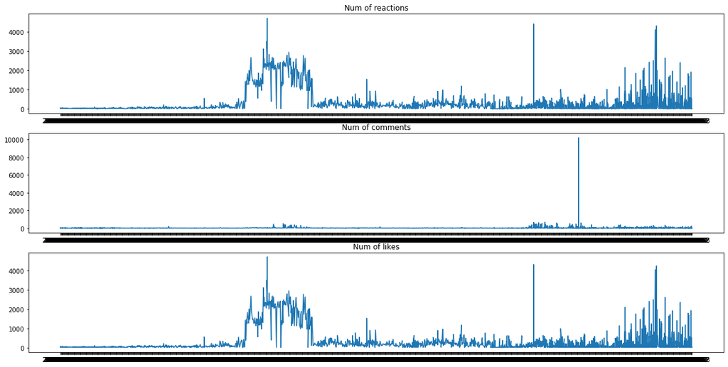

```python
plt.figure(figsize = [20, 10])
plt.subplot(3, 1, 1)
plt.plot(photo['status_published'],photo['num_reactions'])
plt.title('Num of reactions');

plt.subplot(3, 1, 2)
plt.plot(photo['status_published'],photo['num_comments'])
plt.title('Num of comments');

plt.subplot(3, 1, 3)
plt.plot(photo['status_published'],photo['num_likes'])
plt.title('Num of likes');
```

Plot with time, we see recently photo posts has number of reactions about 1000, comments about 0, which is the smallest and likes about 500-1000.

# status

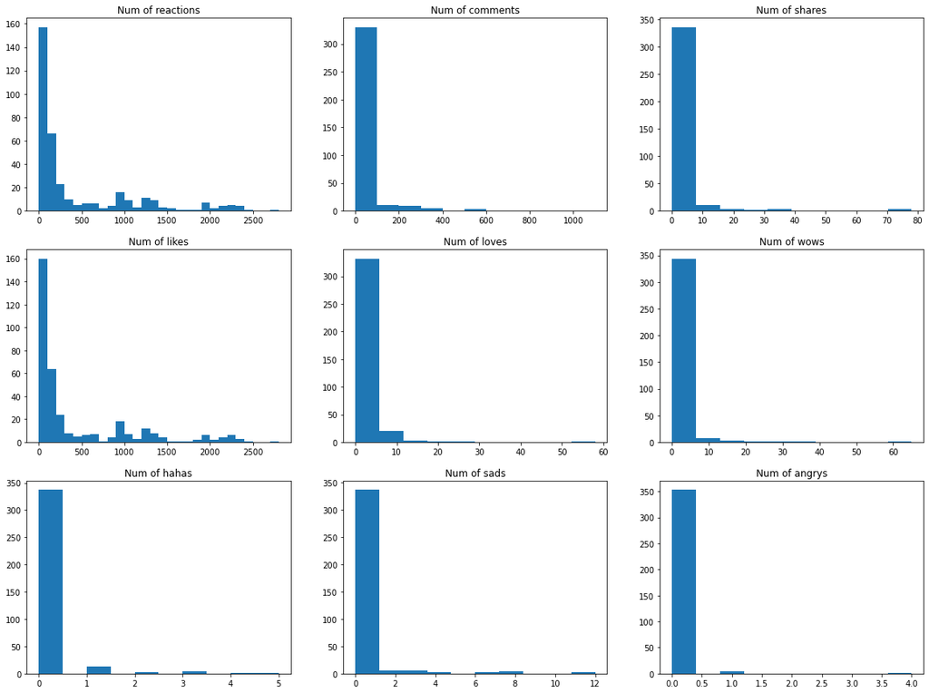

```python
plt.figure(figsize = [20, 15])


plt.subplot(3, 3, 1) # 3 row, 3 cols, subplot 1
bins = np.arange(0, status['num_reactions'].max()+4, 100)
plt.hist(data = status, x = 'num_reactions', bins=bins);
plt.title('Num of reactions');

plt.subplot(3, 3, 2)
bins = np.arange(0, status['num_comments'].max()+4, 100)
plt.hist(data = status, x = 'num_comments', bins=bins);
plt.title('Num of comments');

plt.subplot(3, 3, 3)
plt.hist(data = status, x = 'num_shares');
plt.title('Num of shares');

plt.subplot(3, 3, 4)
bins = np.arange(0, status['num_likes'].max()+4, 100)
plt.hist(data = status, x = 'num_likes', bins=bins);
plt.title('Num of likes');

plt.subplot(3, 3, 5)
plt.hist(data = status, x = 'num_loves');
plt.title('Num of loves');

plt.subplot(3, 3, 6)
plt.hist(data = status, x = 'num_wows');
plt.title('Num of wows');

plt.subplot(3, 3, 7)
plt.hist(data = status, x = 'num_hahas');
plt.title('Num of hahas');

plt.subplot(3, 3, 8)
plt.hist(data = status, x = 'num_sads');
plt.title('Num of sads');

plt.subplot(3, 3, 9)
plt.hist(data = status, x = 'num_angrys');
plt.title('Num of angrys');
```

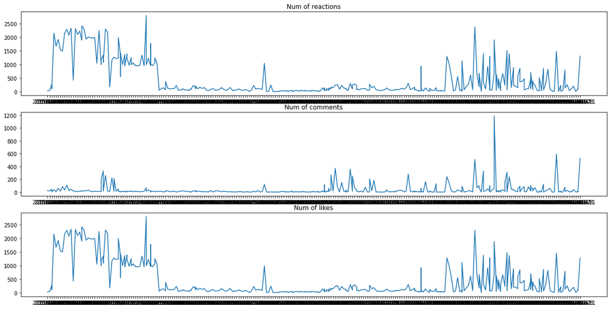

```python
plt.figure(figsize = [20, 10])
plt.subplot(3, 1, 1)
plt.plot(status['status_published'],status['num_reactions'])
plt.title('Num of reactions');

plt.subplot(3, 1, 2)
plt.plot(status['status_published'],status['num_comments'])
plt.title('Num of comments');

plt.subplot(3, 1, 3)
plt.plot(status['status_published'],status['num_likes'])
plt.title('Num of likes');
```

Plot with time, we see recently status posts has number of reactions about 500-1000, comments about 0-200 and likes about 500-1000.

# video

```python
video = df_copy[df_copy['status_type']=='video']
video.describe()
```

|  | num_reactions | num_comments | num_shares | num_likes | num_loves | num_wows | num_hahas | num_sads | num_angrys |
| --- | --- | --- | --- | --- | --- | --- | --- | --- | --- |
| count | 2333.000000 | 2333.000000 | 2333.000000 | 2333.000000 | 2333.000000 | 2333.000000 | 2333.000000 | 2333.000000 | 2333.000000 |
| mean | 283.369910 | 642.744964 | 115.728247 | 242.967853 | 35.547364 | 2.447921 | 1.735962 | 0.414059 | 0.254179 |
| std | 446.696999 | 1442.453954 | 207.011857 | 413.261014 | 63.339545 | 14.628283 | 6.047459 | 1.478261 | 0.712024 |
| min | 0.000000 | 0.000000 | 0.000000 | 0.000000 | 0.000000 | 0.000000 | 0.000000 | 0.000000 | 0.000000 |
| 25% | 28.000000 | 0.000000 | 0.000000 | 27.000000 | 0.000000 | 0.000000 | 0.000000 | 0.000000 | 0.000000 |
| 50% | 160.000000 | 39.000000 | 12.000000 | 117.000000 | 3.000000 | 0.000000 | 0.000000 | 0.000000 | 0.000000 |
| 75% | 296.000000 | 672.000000 | 169.000000 | 238.000000 | 49.000000 | 1.000000 | 2.000000 | 0.000000 | 0.000000 |
| max | 4094.000000 | 20990.000000 | 3424.000000 | 4094.000000 | 657.000000 | 278.000000 | 157.000000 | 37.000000 | 8.000000 |

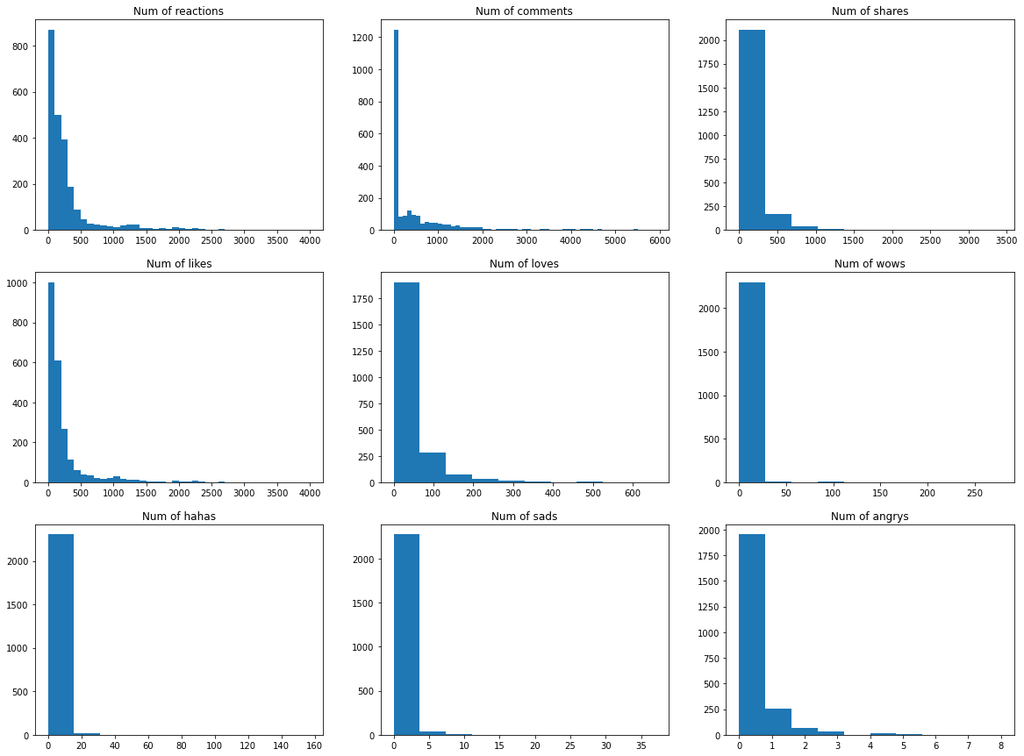

```python
plt.figure(figsize = [20, 15])


plt.subplot(3, 3, 1) # 3 row, 3 cols, subplot 1
bins = np.arange(0, video['num_reactions'].max()+4, 100)
plt.hist(data = video, x = 'num_reactions', bins=bins);
plt.title('Num of reactions');

plt.subplot(3, 3, 2)
bins = np.arange(0, 6000, 100)
plt.hist(data = video, x = 'num_comments', bins=bins);
plt.title('Num of comments');

plt.subplot(3, 3, 3)
plt.hist(data = video, x = 'num_shares');
plt.title('Num of shares');

plt.subplot(3, 3, 4)
bins = np.arange(0, video['num_likes'].max()+4, 100)
plt.hist(data = video, x = 'num_likes', bins=bins);
plt.title('Num of likes');

plt.subplot(3, 3, 5)
plt.hist(data = video, x = 'num_loves');
plt.title('Num of loves');

plt.subplot(3, 3, 6)
plt.hist(data = video, x = 'num_wows');
plt.title('Num of wows');

plt.subplot(3, 3, 7)
plt.hist(data = video, x = 'num_hahas');
plt.title('Num of hahas');

plt.subplot(3, 3, 8)
plt.hist(data = video, x = 'num_sads');
plt.title('Num of sads');

plt.subplot(3, 3, 9)
plt.hist(data = video, x = 'num_angrys');
plt.title('Num of angrys');
```

we have number of reactions with a median of **160** and a mean of **283.37**. Number of comments with a median of **39** and a mean of **642.74**. Video has a much higher comments number. Number of emotions are higher than other type of posts.

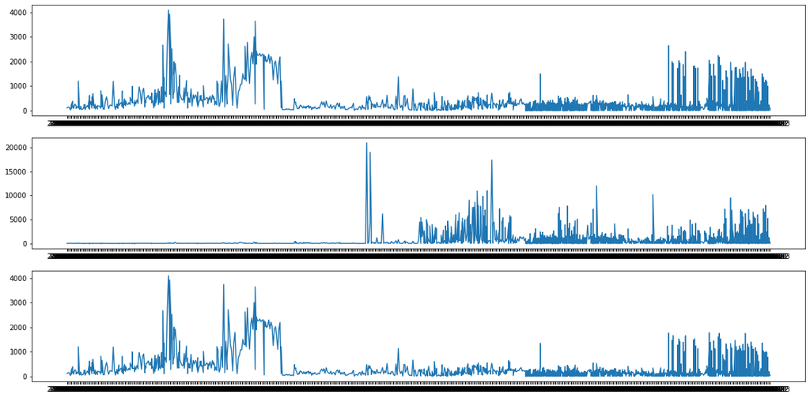

```python
plt.figure(figsize = [20, 10])
plt.subplot(3, 1, 1)
plt.plot(video['status_published'],video['num_reactions'])
plt.title('Num of reactions');

plt.subplot(3, 1, 2)
plt.plot(video['status_published'],video['num_comments'])
plt.title('Num of comments');

plt.subplot(3, 1, 3)
plt.plot(video['status_published'],video['num_likes'])
plt.title('Num of likes');
```

Plot with time, we see recently video posts has number of reactions about 1000-2000, comments about 3000-5000 and likes about 1000.

# compare

```python
category_means_reaction = df_copy.groupby('status_type').num_reactions.mean()
category_means_reaction
```

[output not shown]

Status has the highest status compare to other type of posts.

```python
category_means_comments = df_copy.groupby('status_type').num_comments.mean()
category_means_comments
```

[output not shown]

```python
category_means_shares = df_copy.groupby('status_type').num_shares.mean()
category_means_shares
```

```
status_type
link        4.396825
photo       2.491517
status      2.576602
video     115.728247
Name: num_shares, dtype: float64
```

We see video has a much higher comments and shares compare to other types of post.